# Predictive Model Building

# 1 MVP

We’ve looked at a few different ways in which we can build models this week, including how to prepare them properly. This weekend we’ll build a multiple linear regression model on a dataset which will need some preparation. The data can be found in the data folder, along with a data dictionary

We want to investigate the avocado dataset, and, in particular, to model the `AveragePrice` of the avocados. Use the tools we’ve worked with this week in order to prepare your dataset and find appropriate predictors. Once you’ve built your model use the validation techniques discussed on Wednesday to evaluate it. Feel free to focus either on building an *explanatory* or a *predictive* model, or both if you are feeling energetic!

As part of the MVP we want you not to just run the code but also have a go at **intepreting the results** and write your thinking in comments in your script.

**Hints and tips**

- `region` may lead to many dummy variables. Think carefully about whether to include this variable or not (there is no one ‘right’ answer to this!)
- Think about whether each variable is *categorical* or *numerical*. If categorical, make sure that the variable is represented as a factor.
- We will not treat this data as a time series, so `Date` will not be needed in your models, but can you extract any useful features out of `Date` before you discard it?
- If you want to build a predictive model, consider using either `leaps` or `glmulti` to help with this.

Here we are ‘trusting’ the machine to do the heavy lifting, so little intervention expected…

```r
library(tidyverse)
library(janitor)
library(ggfortify)
library(GGally)
library(leaps)
library(glmulti)
library(lubridate)
avocado_df <- read_csv("data/avocado.csv") %>%
  clean_names()
avocado_tidy <- avocado_df %>%
  filter(region != "TotalUS") %>%
  mutate(type = as.factor(type)) %>%
  mutate(year = as.factor(year))
```

```r
avocado_tidy_with_region <- avocado_df %>%
  filter(region != "TotalUS") %>%
  mutate(type = as.factor(type)) %>%
  mutate(year = as.factor(year)) %>%
  mutate(region = as.factor(region)) %>%
  select(-date)
```

```r
avocado_tidy_with_region_factorised <- avocado_df %>%
  filter(region != "TotalUS") %>%
  mutate(type = as.factor(type)) %>%
  mutate(year = as.factor(year)) %>%
  mutate(region = as.factor(region)) %>%
  mutate(x1 = as.factor(x1)) %>%
  select(-date)
```

```r
avocado_tidy_total_usa <- avocado_df %>%
  filter(region == "TotalUS") %>%
  mutate(type = as.factor(type)) %>%
  mutate(year = as.factor(year)) %>%
  select(-c(date, region))
```

```r
avocado_tidy_total_usa_factorised <- avocado_df %>%
  filter(region == "TotalUS") %>%
  mutate(type = as.factor(type)) %>%
  mutate(year = as.factor(year)) %>%
  mutate(x1 = as.factor(x1)) %>%
  select(-c(date, region))
```

```r
avocado_tidy_season_total_usa <- avocado_df %>%
  mutate(month = as.character(month(date))) %>%
  mutate(season = case_when(
           month == "12" | month == "1" | month == "2" ~ "winter",
           month == "3" | month == "4" | month == "5" ~ "spring",
           month == "6" | month == "7" | month == "8" ~ "summer",
           month == "9" | month == "10" | month == "11" ~ "autumn")
         ) %>%
  filter(region == "TotalUS") %>%
  mutate(type = as.factor(type)) %>%
  mutate(year = as.factor(year)) %>%
  mutate(season = as.factor(season)) %>%
  select(-c(date, region))
```

```r
avocado_tidy_season_total_usa_factorised <- avocado_df %>%
  mutate(month = as.character(month(date))) %>%
  mutate(season = case_when(
           month == "12" | month == "1" | month == "2" ~ "winter",
           month == "3" | month == "4" | month == "5" ~ "spring",
           month == "6" | month == "7" | month == "8" ~ "summer",
           month == "9" | month == "10" | month == "11" ~ "autumn")
         ) %>%
  filter(region == "TotalUS") %>%
  mutate(type = as.factor(type)) %>%
  mutate(year = as.factor(year)) %>%
  mutate(season = as.factor(season)) %>%
  mutate(x1 = as.factor(x1)) %>%
  select(-c(date, region))
```

## 1.1 Scenarios

Automated model development using the **forward selection** method from **regsubsets()** function in **leaps** package.

### 1.1.1 Keeping **region** in

```r
regsubsets_forward_region <- regsubsets(average_price ~ ., data = avocado_tidy_with_region, method = "forward")
```

### 1.1.2 Keeping **region** in - factorised

```r
regsubsets_forward_region_factorised <- regsubsets(average_price ~ ., data = avocado_tidy_with_region_factorised, method = "forward")
```

### 1.1.3 “region” removed, only total USA

```r
regsubsets_forward_total_usa <- regsubsets(average_price ~ ., data = avocado_tidy_total_usa, method = "forward")
```

### 1.1.4 “region” removed, only total USA - factorised

```r
regsubsets_forward_total_usa_factorised <- regsubsets(average_price ~ ., data = avocado_tidy_total_usa_factorised, method = "forward")
```

### 1.1.5 Adding *season* to ‘total USA’

```r
regsubsets_forward_season_total_usa <- regsubsets(average_price ~ ., data = avocado_tidy_season_total_usa, method = "forward")
```

### 1.1.6 Adding *season* to ‘total USA’ factorised x1

```r
regsubsets_forward_season_total_usa_factorised <- regsubsets(average_price ~ ., data = avocado_tidy_season_total_usa_factorised, method = "forward")
```

### 1.1.7 Running model on tidy initial data

```r
regsubsets_forward_avocado_tidy <- regsubsets(average_price ~ ., data = avocado_tidy, method = "forward")
```

### 1.1.8 Running model on initial data

```r
regsubsets_forward_avocado_df <- regsubsets(average_price ~ ., data = avocado_df, method = "forward")
```

## 1.2 Examining model results

### 1.2.1 **region** in model

```r
sum_regsubsets_forward_region <- summary(regsubsets_forward_region)
sum_regsubsets_forward_region
```

```
## Subset selection object
## Call: regsubsets.formula(average_price ~ ., data = avocado_tidy_with_region,
##     method = "forward")
## 65 Variables  (and intercept)
##                           Forced in Forced out
## x1                            FALSE      FALSE
## total_volume                  FALSE      FALSE
## x4046                         FALSE      FALSE
## x4225                         FALSE      FALSE
## x4770                         FALSE      FALSE
## total_bags                    FALSE      FALSE
## small_bags                    FALSE      FALSE
## large_bags                    FALSE      FALSE
## x_large_bags                  FALSE      FALSE
## typeorganic                   FALSE      FALSE
## year2016                      FALSE      FALSE
## year2017                      FALSE      FALSE
## year2018                      FALSE      FALSE
## regionAtlanta                 FALSE      FALSE
## regionBaltimoreWashington     FALSE      FALSE
## regionBoise                   FALSE      FALSE
## regionBoston                  FALSE      FALSE
## regionBuffaloRochester        FALSE      FALSE
## regionCalifornia              FALSE      FALSE
## regionCharlotte               FALSE      FALSE
## regionChicago                 FALSE      FALSE
## regionCincinnatiDayton        FALSE      FALSE
## regionColumbus                FALSE      FALSE
## regionDallasFtWorth           FALSE      FALSE
## regionDenver                  FALSE      FALSE
## regionDetroit                 FALSE      FALSE
## regionGrandRapids             FALSE      FALSE
## regionGreatLakes              FALSE      FALSE
## regionHarrisburgScranton      FALSE      FALSE
## regionHartfordSpringfield     FALSE      FALSE
## regionHouston                 FALSE      FALSE
## regionIndianapolis            FALSE      FALSE
## regionJacksonville            FALSE      FALSE
## regionLasVegas                FALSE      FALSE
## regionLosAngeles              FALSE      FALSE
```

[output cut: 170 more lines]

```
## 3  ( 1 ) " "           " "            " "         " "
## 4  ( 1 ) " "           " "            " "         " "
## 5  ( 1 ) " "           " "            " "         " "
## 6  ( 1 ) " "           " "            " "         " "
## 7  ( 1 ) " "           " "            " "         " "
## 8  ( 1 ) " "           " "            " "         " "
##          regionWestTexNewMexico
## 1  ( 1 ) " "
## 2  ( 1 ) " "
## 3  ( 1 ) " "
## 4  ( 1 ) " "
## 5  ( 1 ) " "
## 6  ( 1 ) " "
## 7  ( 1 ) " "
## 8  ( 1 ) " "
```

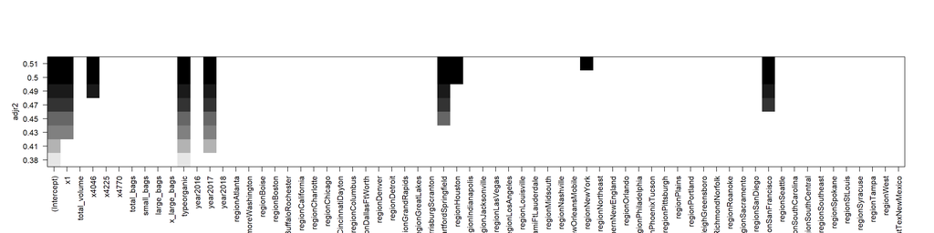

```r
plot(regsubsets_forward_region, scale = "adjr2")
```

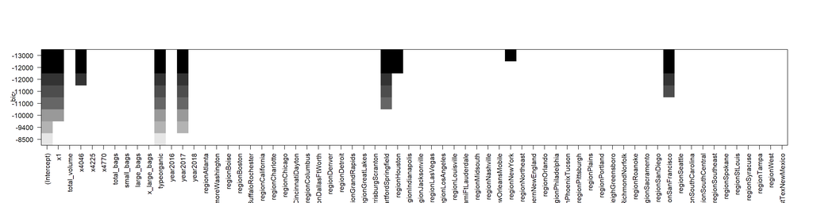

```r
plot(regsubsets_forward_region, scale = "bic")
```

### 1.2.2 **region** in model - factorised x1

```r
sum_regsubsets_forward_region_factorised <- summary(regsubsets_forward_region_factorised)
sum_regsubsets_forward_region_factorised
```

```
## Subset selection object
## Call: regsubsets.formula(average_price ~ ., data = avocado_tidy_with_region_factorised,
##     method = "forward")
## 116 Variables  (and intercept)
##                           Forced in Forced out
## x11                           FALSE      FALSE
## x12                           FALSE      FALSE
## x13                           FALSE      FALSE
## x14                           FALSE      FALSE
## x15                           FALSE      FALSE
## x16                           FALSE      FALSE
## x17                           FALSE      FALSE
## x18                           FALSE      FALSE
## x19                           FALSE      FALSE
## x110                          FALSE      FALSE
## x111                          FALSE      FALSE
## x112                          FALSE      FALSE
## x113                          FALSE      FALSE
## x114                          FALSE      FALSE
## x115                          FALSE      FALSE
## x116                          FALSE      FALSE
## x117                          FALSE      FALSE
## x118                          FALSE      FALSE
## x119                          FALSE      FALSE
## x120                          FALSE      FALSE
## x121                          FALSE      FALSE
## x122                          FALSE      FALSE
## x123                          FALSE      FALSE
## x124                          FALSE      FALSE
## x125                          FALSE      FALSE
## x126                          FALSE      FALSE
## x127                          FALSE      FALSE
## x128                          FALSE      FALSE
## x129                          FALSE      FALSE
## x130                          FALSE      FALSE
## x131                          FALSE      FALSE
## x132                          FALSE      FALSE
## x133                          FALSE      FALSE
## x134                          FALSE      FALSE
## x135                          FALSE      FALSE
```

[output cut: 248 more lines]

```
## 3  ( 1 ) " "           " "           " "            " "         " "
## 4  ( 1 ) " "           " "           " "            " "         " "
## 5  ( 1 ) " "           " "           " "            " "         " "
## 6  ( 1 ) " "           " "           " "            " "         " "
## 7  ( 1 ) " "           " "           " "            " "         " "
## 8  ( 1 ) " "           " "           " "            " "         " "
##          regionWestTexNewMexico
## 1  ( 1 ) " "
## 2  ( 1 ) " "
## 3  ( 1 ) " "
## 4  ( 1 ) " "
## 5  ( 1 ) " "
## 6  ( 1 ) " "
## 7  ( 1 ) " "
## 8  ( 1 ) " "
```

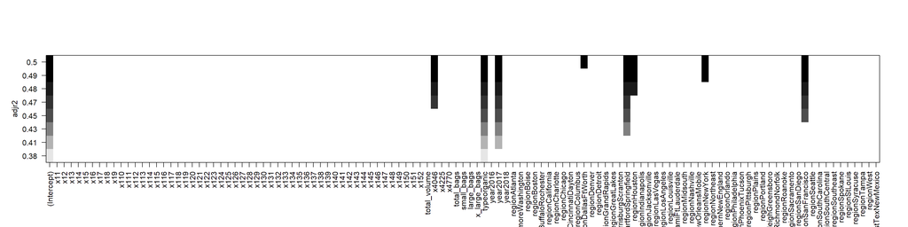

```r
plot(regsubsets_forward_region_factorised, scale = "adjr2")
```

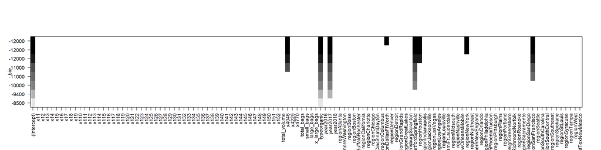

```r
plot(regsubsets_forward_region_factorised, scale = "bic")
```

### 1.2.3 **total usa** model

```r
sum_regsubsets_forward_total_usa <- summary(regsubsets_forward_total_usa)
sum_regsubsets_forward_total_usa
```

```
## Subset selection object
## Call: regsubsets.formula(average_price ~ ., data = avocado_tidy_total_usa,
##     method = "forward")
## 13 Variables  (and intercept)
##              Forced in Forced out
## x1               FALSE      FALSE
## total_volume     FALSE      FALSE
## x4046            FALSE      FALSE
## x4225            FALSE      FALSE
## x4770            FALSE      FALSE
## total_bags       FALSE      FALSE
## small_bags       FALSE      FALSE
## large_bags       FALSE      FALSE
## x_large_bags     FALSE      FALSE
## typeorganic      FALSE      FALSE
## year2016         FALSE      FALSE
## year2017         FALSE      FALSE
## year2018         FALSE      FALSE
## 1 subsets of each size up to 8
## Selection Algorithm: forward
##          x1  total_volume x4046 x4225 x4770 total_bags small_bags large_bags
## 1  ( 1 ) " " " "          " "   "*"   " "   " "        " "        " "
## 2  ( 1 ) " " " "          " "   "*"   " "   " "        " "        " "
## 3  ( 1 ) "*" " "          " "   "*"   " "   " "        " "        " "
## 4  ( 1 ) "*" " "          " "   "*"   " "   " "        " "        "*"
## 5  ( 1 ) "*" " "          " "   "*"   " "   " "        " "        "*"
## 6  ( 1 ) "*" " "          " "   "*"   " "   "*"        " "        "*"
## 7  ( 1 ) "*" " "          " "   "*"   " "   "*"        "*"        "*"
## 8  ( 1 ) "*" " "          " "   "*"   "*"   "*"        "*"        "*"
##          x_large_bags typeorganic year2016 year2017 year2018
## 1  ( 1 ) " "          " "         " "      " "      " "
## 2  ( 1 ) " "          " "         " "      "*"      " "
## 3  ( 1 ) " "          " "         " "      "*"      " "
## 4  ( 1 ) " "          " "         " "      "*"      " "
## 5  ( 1 ) "*"          " "         " "      "*"      " "
## 6  ( 1 ) "*"          " "         " "      "*"      " "
## 7  ( 1 ) "*"          " "         " "      "*"      " "
## 8  ( 1 ) "*"          " "         " "      "*"      " "
```

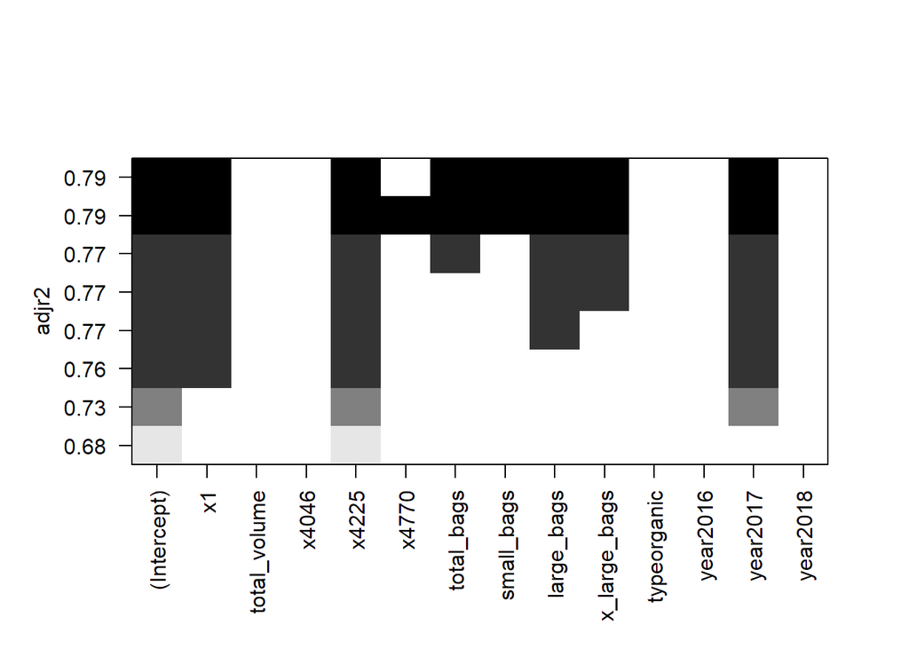

```r
plot(regsubsets_forward_total_usa, scale = "adjr2")
```

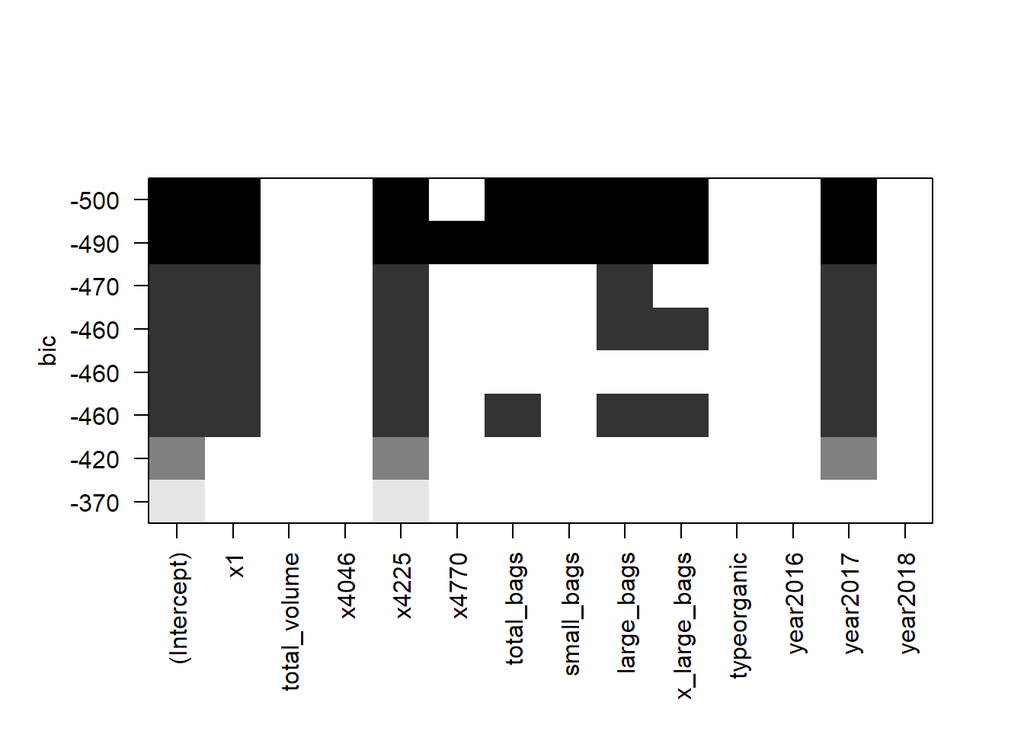

```r
plot(regsubsets_forward_total_usa, scale = "bic")
```

### 1.2.4 **total usa** model - factorised

```r
sum_regsubsets_forward_total_usa_factorised <- summary(regsubsets_forward_total_usa_factorised)
sum_regsubsets_forward_total_usa_factorised
```

```
## Subset selection object
## Call: regsubsets.formula(average_price ~ ., data = avocado_tidy_total_usa_factorised,
##     method = "forward")
## 64 Variables  (and intercept)
##              Forced in Forced out
## x11              FALSE      FALSE
## x12              FALSE      FALSE
## x13              FALSE      FALSE
## x14              FALSE      FALSE
## x15              FALSE      FALSE
## x16              FALSE      FALSE
## x17              FALSE      FALSE
## x18              FALSE      FALSE
## x19              FALSE      FALSE
## x110             FALSE      FALSE
## x111             FALSE      FALSE
## x112             FALSE      FALSE
## x113             FALSE      FALSE
## x114             FALSE      FALSE
## x115             FALSE      FALSE
## x116             FALSE      FALSE
## x117             FALSE      FALSE
## x118             FALSE      FALSE
## x119             FALSE      FALSE
## x120             FALSE      FALSE
## x121             FALSE      FALSE
## x122             FALSE      FALSE
## x123             FALSE      FALSE
## x124             FALSE      FALSE
## x125             FALSE      FALSE
## x126             FALSE      FALSE
## x127             FALSE      FALSE
## x128             FALSE      FALSE
## x129             FALSE      FALSE
## x130             FALSE      FALSE
## x131             FALSE      FALSE
## x132             FALSE      FALSE
## x133             FALSE      FALSE
## x134             FALSE      FALSE
## x135             FALSE      FALSE
```

[output cut: 70 more lines]

```
## 3  ( 1 ) " "        " "        " "        " "          " "         " "
## 4  ( 1 ) " "        " "        " "        " "          " "         " "
## 5  ( 1 ) " "        " "        " "        " "          " "         " "
## 6  ( 1 ) " "        " "        " "        " "          " "         " "
## 7  ( 1 ) " "        " "        " "        " "          " "         " "
## 8  ( 1 ) " "        " "        " "        " "          " "         " "
##          year2017 year2018
## 1  ( 1 ) " "      " "
## 2  ( 1 ) "*"      " "
## 3  ( 1 ) "*"      " "
## 4  ( 1 ) "*"      " "
## 5  ( 1 ) "*"      " "
## 6  ( 1 ) "*"      " "
## 7  ( 1 ) "*"      " "
## 8  ( 1 ) "*"      " "
```

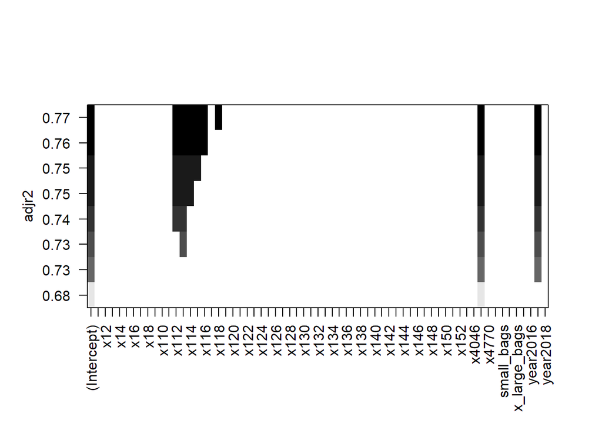

```r
plot(regsubsets_forward_total_usa_factorised, scale = "adjr2")
```

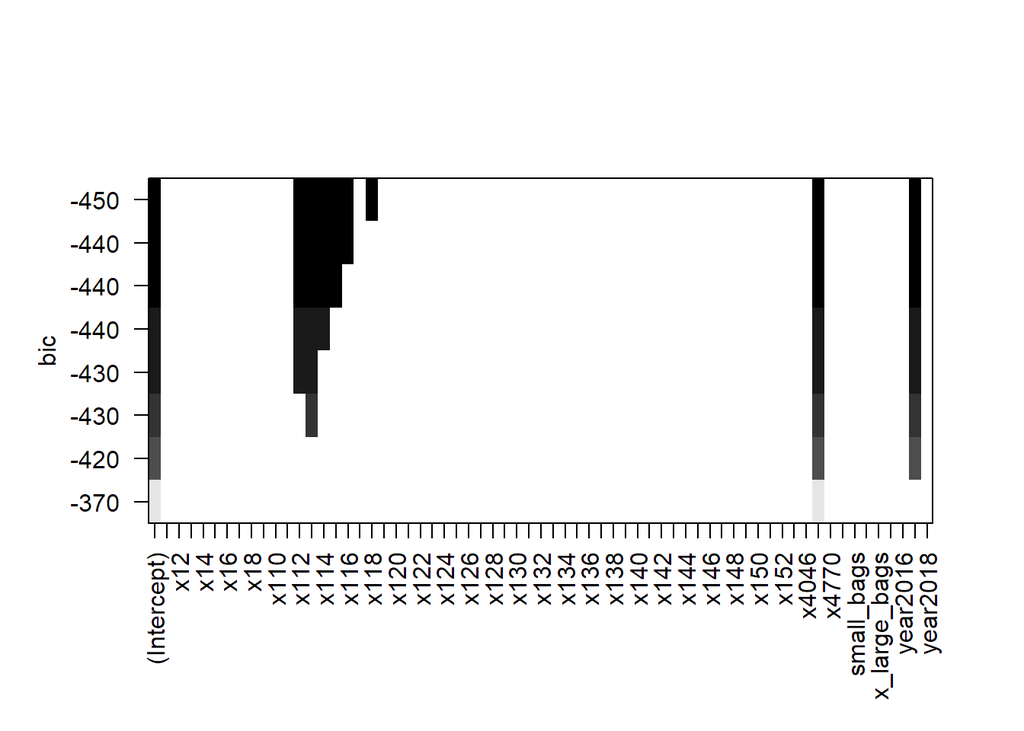

```r
plot(regsubsets_forward_total_usa_factorised, scale = "bic")
```

### 1.2.5 **season** and **total_usa** model

```r
sum_regsubsets_forward_season_total_usa <- summary(regsubsets_forward_season_total_usa)
sum_regsubsets_forward_season_total_usa
```

```
## Subset selection object
## Call: regsubsets.formula(average_price ~ ., data = avocado_tidy_season_total_usa,
##     method = "forward")
## 27 Variables  (and intercept)
##              Forced in Forced out
## x1               FALSE      FALSE
## total_volume     FALSE      FALSE
## x4046            FALSE      FALSE
## x4225            FALSE      FALSE
## x4770            FALSE      FALSE
## total_bags       FALSE      FALSE
## small_bags       FALSE      FALSE
## large_bags       FALSE      FALSE
## x_large_bags     FALSE      FALSE
## typeorganic      FALSE      FALSE
## year2016         FALSE      FALSE
## year2017         FALSE      FALSE
## year2018         FALSE      FALSE
## month10          FALSE      FALSE
## month11          FALSE      FALSE
## month12          FALSE      FALSE
## month2           FALSE      FALSE
## month3           FALSE      FALSE
## month4           FALSE      FALSE
## month5           FALSE      FALSE
## month6           FALSE      FALSE
## month7           FALSE      FALSE
## month8           FALSE      FALSE
## month9           FALSE      FALSE
## seasonspring     FALSE      FALSE
## seasonsummer     FALSE      FALSE
## seasonwinter     FALSE      FALSE
## 1 subsets of each size up to 8
## Selection Algorithm: forward
##          x1  total_volume x4046 x4225 x4770 total_bags small_bags large_bags
## 1  ( 1 ) " " " "          " "   "*"   " "   " "        " "        " "
## 2  ( 1 ) " " " "          " "   "*"   " "   " "        " "        " "
## 3  ( 1 ) "*" " "          " "   "*"   " "   " "        " "        " "
## 4  ( 1 ) "*" " "          " "   "*"   " "   " "        " "        " "
## 5  ( 1 ) "*" " "          " "   "*"   " "   " "        " "        " "
```

[output cut: 15 more lines]

```
## 3  ( 1 ) " "     " "    " "    " "    " "    " "    " "    " "    " "
## 4  ( 1 ) "*"     " "    " "    " "    " "    " "    " "    " "    " "
## 5  ( 1 ) "*"     " "    " "    " "    " "    " "    " "    " "    "*"
## 6  ( 1 ) "*"     " "    " "    " "    " "    " "    " "    " "    "*"
## 7  ( 1 ) "*"     " "    " "    " "    " "    " "    " "    " "    "*"
## 8  ( 1 ) "*"     " "    " "    " "    " "    " "    " "    " "    "*"
##          seasonspring seasonsummer seasonwinter
## 1  ( 1 ) " "          " "          " "
## 2  ( 1 ) " "          " "          " "
## 3  ( 1 ) " "          " "          " "
## 4  ( 1 ) " "          " "          " "
## 5  ( 1 ) " "          " "          " "
## 6  ( 1 ) " "          " "          " "
## 7  ( 1 ) " "          " "          " "
## 8  ( 1 ) " "          " "          " "
```

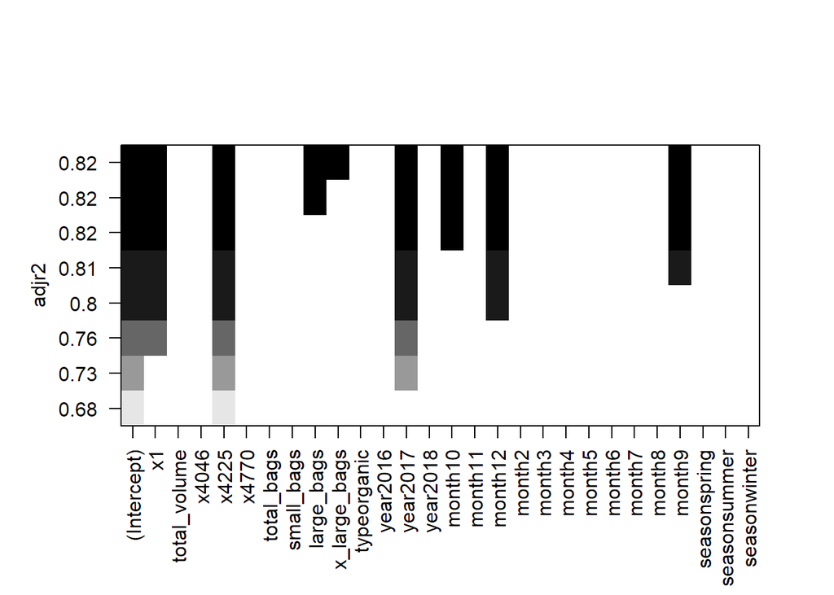

```r
plot(regsubsets_forward_season_total_usa, scale = "adjr2")
```

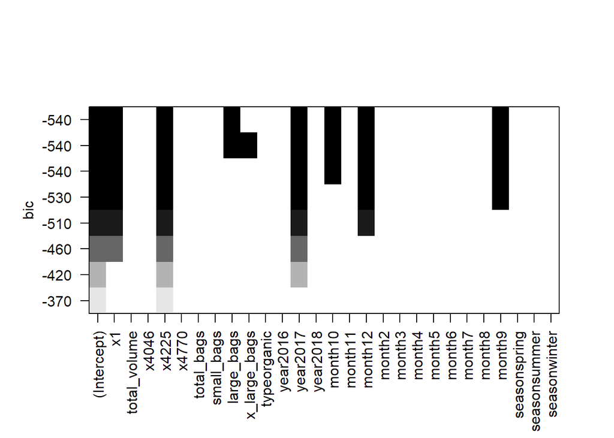

```r
plot(regsubsets_forward_season_total_usa, scale = "bic")
```

### 1.2.6 **season** and **total_usa** model - factorised x1

```r
sum_regsubsets_forward_season_total_usa_factorised <- summary(regsubsets_forward_season_total_usa_factorised)
sum_regsubsets_forward_season_total_usa_factorised
```

```
## Subset selection object
## Call: regsubsets.formula(average_price ~ ., data = avocado_tidy_season_total_usa_factorised,
##     method = "forward")
## 78 Variables  (and intercept)
##              Forced in Forced out
## x11              FALSE      FALSE
## x12              FALSE      FALSE
## x13              FALSE      FALSE
## x14              FALSE      FALSE
## x15              FALSE      FALSE
## x16              FALSE      FALSE
## x17              FALSE      FALSE
## x18              FALSE      FALSE
## x19              FALSE      FALSE
## x110             FALSE      FALSE
## x111             FALSE      FALSE
## x112             FALSE      FALSE
## x113             FALSE      FALSE
## x114             FALSE      FALSE
## x115             FALSE      FALSE
## x116             FALSE      FALSE
## x117             FALSE      FALSE
## x118             FALSE      FALSE
## x119             FALSE      FALSE
## x120             FALSE      FALSE
## x121             FALSE      FALSE
## x122             FALSE      FALSE
## x123             FALSE      FALSE
## x124             FALSE      FALSE
## x125             FALSE      FALSE
## x126             FALSE      FALSE
## x127             FALSE      FALSE
## x128             FALSE      FALSE
## x129             FALSE      FALSE
## x130             FALSE      FALSE
## x131             FALSE      FALSE
## x132             FALSE      FALSE
## x133             FALSE      FALSE
## x134             FALSE      FALSE
## x135             FALSE      FALSE
```

[output cut: 93 more lines]

```
## 3  ( 1 ) "*"      " "      " "     " "     " "     " "    " "    " "    " "
## 4  ( 1 ) "*"      " "      "*"     " "     " "     " "    " "    " "    " "
## 5  ( 1 ) "*"      " "      "*"     " "     " "     " "    " "    " "    " "
## 6  ( 1 ) "*"      "*"      "*"     " "     " "     " "    " "    " "    " "
## 7  ( 1 ) "*"      "*"      "*"     "*"     " "     " "    " "    " "    " "
## 8  ( 1 ) "*"      "*"      "*"     "*"     " "     " "    " "    " "    "*"
##          month6 month7 month8 month9 seasonspring seasonsummer seasonwinter
## 1  ( 1 ) " "    " "    " "    " "    " "          " "          " "
## 2  ( 1 ) " "    " "    " "    " "    " "          " "          " "
## 3  ( 1 ) " "    " "    " "    "*"    " "          " "          " "
## 4  ( 1 ) " "    " "    " "    "*"    " "          " "          " "
## 5  ( 1 ) " "    " "    " "    "*"    " "          "*"          " "
## 6  ( 1 ) " "    " "    " "    "*"    " "          "*"          " "
## 7  ( 1 ) " "    " "    " "    "*"    " "          "*"          " "
## 8  ( 1 ) " "    " "    " "    "*"    " "          "*"          " "
```

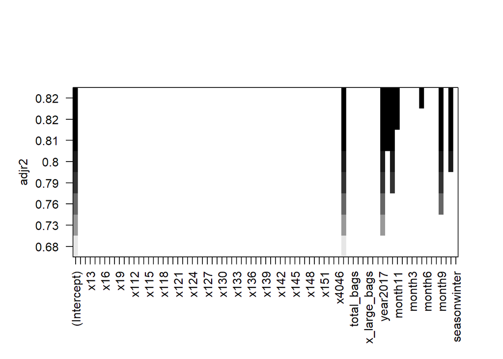

```r
plot(regsubsets_forward_season_total_usa_factorised, scale = "adjr2")
```

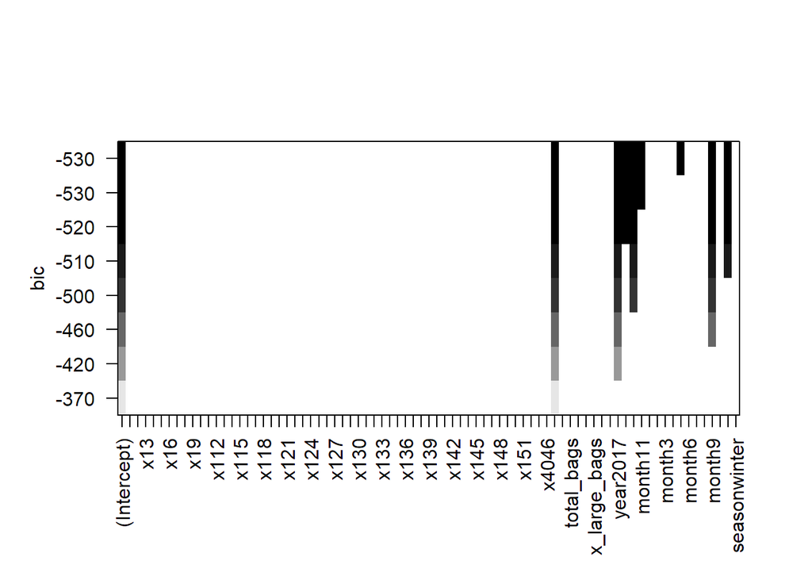

```r
plot(regsubsets_forward_season_total_usa_factorised, scale = "bic")
```

### 1.2.7 **initial dataset tidy**

```r
sum_regsubsets_forward_avocado_tidy <- summary(regsubsets_forward_avocado_tidy)
sum_regsubsets_forward_avocado_tidy
```

```
## Subset selection object
## Call: regsubsets.formula(average_price ~ ., data = avocado_tidy, method = "forward")
## 66 Variables  (and intercept)
##                           Forced in Forced out
## x1                            FALSE      FALSE
## date                          FALSE      FALSE
## total_volume                  FALSE      FALSE
## x4046                         FALSE      FALSE
## x4225                         FALSE      FALSE
## x4770                         FALSE      FALSE
## total_bags                    FALSE      FALSE
## small_bags                    FALSE      FALSE
## large_bags                    FALSE      FALSE
## x_large_bags                  FALSE      FALSE
## typeorganic                   FALSE      FALSE
## year2016                      FALSE      FALSE
## year2017                      FALSE      FALSE
## year2018                      FALSE      FALSE
## regionAtlanta                 FALSE      FALSE
## regionBaltimoreWashington     FALSE      FALSE
## regionBoise                   FALSE      FALSE
## regionBoston                  FALSE      FALSE
## regionBuffaloRochester        FALSE      FALSE
## regionCalifornia              FALSE      FALSE
## regionCharlotte               FALSE      FALSE
## regionChicago                 FALSE      FALSE
## regionCincinnatiDayton        FALSE      FALSE
## regionColumbus                FALSE      FALSE
## regionDallasFtWorth           FALSE      FALSE
## regionDenver                  FALSE      FALSE
## regionDetroit                 FALSE      FALSE
## regionGrandRapids             FALSE      FALSE
## regionGreatLakes              FALSE      FALSE
## regionHarrisburgScranton      FALSE      FALSE
## regionHartfordSpringfield     FALSE      FALSE
## regionHouston                 FALSE      FALSE
## regionIndianapolis            FALSE      FALSE
## regionJacksonville            FALSE      FALSE
## regionLasVegas                FALSE      FALSE
## regionLosAngeles              FALSE      FALSE
```

[output cut: 170 more lines]

```
## 3  ( 1 ) " "           " "            " "         " "
## 4  ( 1 ) " "           " "            " "         " "
## 5  ( 1 ) " "           " "            " "         " "
## 6  ( 1 ) " "           " "            " "         " "
## 7  ( 1 ) " "           " "            " "         " "
## 8  ( 1 ) " "           " "            " "         " "
##          regionWestTexNewMexico
## 1  ( 1 ) " "
## 2  ( 1 ) " "
## 3  ( 1 ) " "
## 4  ( 1 ) " "
## 5  ( 1 ) " "
## 6  ( 1 ) " "
## 7  ( 1 ) " "
## 8  ( 1 ) " "
```

### 1.2.8 **intital dataset** model

```r
sum_regsubsets_forward_avocado_df <- summary(regsubsets_forward_avocado_df)
sum_regsubsets_forward_avocado_df
```

```
## Subset selection object
## Call: regsubsets.formula(average_price ~ ., data = avocado_df, method = "forward")
## 65 Variables  (and intercept)
##                           Forced in Forced out
## x1                            FALSE      FALSE
## date                          FALSE      FALSE
## total_volume                  FALSE      FALSE
## x4046                         FALSE      FALSE
## x4225                         FALSE      FALSE
## x4770                         FALSE      FALSE
## total_bags                    FALSE      FALSE
## small_bags                    FALSE      FALSE
## large_bags                    FALSE      FALSE
## x_large_bags                  FALSE      FALSE
## typeorganic                   FALSE      FALSE
## year                          FALSE      FALSE
## regionAtlanta                 FALSE      FALSE
## regionBaltimoreWashington     FALSE      FALSE
## regionBoise                   FALSE      FALSE
## regionBoston                  FALSE      FALSE
## regionBuffaloRochester        FALSE      FALSE
## regionCalifornia              FALSE      FALSE
## regionCharlotte               FALSE      FALSE
## regionChicago                 FALSE      FALSE
## regionCincinnatiDayton        FALSE      FALSE
## regionColumbus                FALSE      FALSE
## regionDallasFtWorth           FALSE      FALSE
## regionDenver                  FALSE      FALSE
## regionDetroit                 FALSE      FALSE
## regionGrandRapids             FALSE      FALSE
## regionGreatLakes              FALSE      FALSE
## regionHarrisburgScranton      FALSE      FALSE
## regionHartfordSpringfield     FALSE      FALSE
## regionHouston                 FALSE      FALSE
## regionIndianapolis            FALSE      FALSE
## regionJacksonville            FALSE      FALSE
## regionLasVegas                FALSE      FALSE
## regionLosAngeles              FALSE      FALSE
## regionLouisville              FALSE      FALSE
## regionMiamiFtLauderdale       FALSE      FALSE
```

[output cut: 169 more lines]

```
## 3  ( 1 ) " "           " "            " "         " "           " "
## 4  ( 1 ) " "           " "            " "         " "           " "
## 5  ( 1 ) " "           " "            " "         " "           " "
## 6  ( 1 ) " "           " "            " "         " "           " "
## 7  ( 1 ) " "           " "            " "         " "           " "
## 8  ( 1 ) " "           " "            " "         " "           " "
##          regionWestTexNewMexico
## 1  ( 1 ) " "
## 2  ( 1 ) " "
## 3  ( 1 ) " "
## 4  ( 1 ) " "
## 5  ( 1 ) " "
## 6  ( 1 ) " "
## 7  ( 1 ) " "
## 8  ( 1 ) " "
```

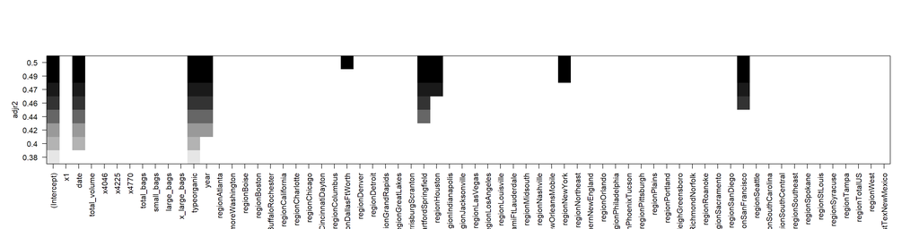

```r
plot(regsubsets_forward_avocado_df, scale = "adjr2")
```

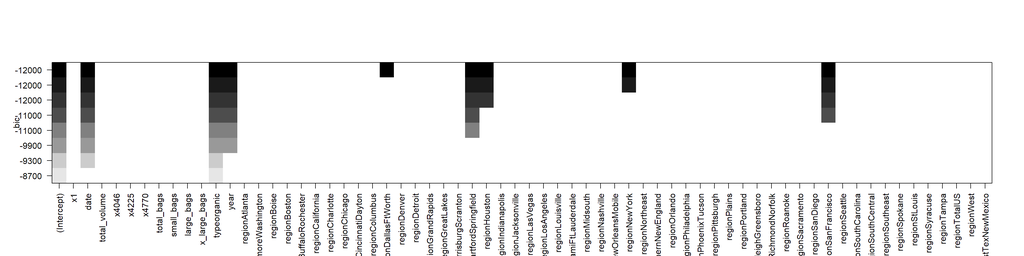

```r
plot(regsubsets_forward_avocado_df, scale = "bic")
```

```r
alias(average_price ~ ., data = avocado_tidy_with_region)
```

```
## Model :
## average_price ~ x1 + total_volume + x4046 + x4225 + x4770 + total_bags +
##     small_bags + large_bags + x_large_bags + type + year + region
```

```r
alias(average_price ~ ., data = avocado_tidy_total_usa)
```

```
## Model :
## average_price ~ x1 + total_volume + x4046 + x4225 + x4770 + total_bags +
##     small_bags + large_bags + x_large_bags + type + year
```

```r
alias(average_price ~ ., data = avocado_df)
```

```
## Model :
## average_price ~ x1 + date + total_volume + x4046 + x4225 + x4770 +
##     total_bags + small_bags + large_bags + x_large_bags + type +
##     year + region
```

```r
alias(average_price ~ ., data = avocado_tidy_season_total_usa)
```

```
## Model :
## average_price ~ x1 + total_volume + x4046 + x4225 + x4770 + total_bags +
##     small_bags + large_bags + x_large_bags + type + year + month +
##     season
##
## Complete :
##              (Intercept) x1 total_volume x4046 x4225 x4770 total_bags
## seasonspring  0           0  0            0     0     0     0
## seasonsummer  0           0  0            0     0     0     0
## seasonwinter  1           0  0            0     0     0     0
##              small_bags large_bags x_large_bags typeorganic year2016 year2017
## seasonspring  0          0          0            0           0        0
## seasonsummer  0          0          0            0           0        0
## seasonwinter  0          0          0            0           0        0
##              year2018 month10 month11 month12 month2 month3 month4 month5
## seasonspring  0        0       0       0       0      1      1      1
## seasonsummer  0        0       0       0       0      0      0      0
## seasonwinter  0       -1      -1       0       0     -1     -1     -1
##              month6 month7 month8 month9
## seasonspring  0      0      0      0
## seasonsummer  1      1      1      0
## seasonwinter -1     -1     -1     -1
```

```r
alias(average_price ~ ., data = avocado_tidy_with_region_factorised)
```

```
## Model :
## average_price ~ x1 + total_volume + x4046 + x4225 + x4770 + total_bags +
##     small_bags + large_bags + x_large_bags + type + year + region
```

```r
alias(average_price ~ ., data = avocado_tidy_season_total_usa_factorised)
```

```
## Model :
## average_price ~ x1 + total_volume + x4046 + x4225 + x4770 + total_bags +
##     small_bags + large_bags + x_large_bags + type + year + month +
##     season
##
## Complete :
##              (Intercept) x11 x12 x13 x14 x15 x16 x17 x18 x19 x110 x111 x112
## month9        1           0   0   0   0   0   0   0   0   0   0    0    0
## seasonspring  0           0   0   0   0   0   0   0   0   0   0    0    0
## seasonsummer  0           0   0   0   0   0   0   0   0   0   0    0    0
## seasonwinter  0           0   0   0   0   0   0   0   0   0   0    0    0
##              x113 x114 x115 x116 x117 x118 x119 x120 x121 x122 x123 x124 x125
## month9        0    0    0    0    0    0    0    0    0    0    0    0    0
## seasonspring  0    0    0    0    0    0    0    0    0    0    0    0    0
## seasonsummer  0    0    0    0    0    0    0    0    0    0    0    0    0
## seasonwinter  0    0    0    0    0    0    0    0    0    0    0    0    0
##              x126 x127 x128 x129 x130 x131 x132 x133 x134 x135 x136 x137 x138
## month9        0    0    0    0    0    0    0    0    0   -1   -1   -1   -1
## seasonspring  0    0    0    0    0    0    0    0    0    0    0    0    0
## seasonsummer  0    0    0    0    0    0    0    0    0    0    0    0    0
## seasonwinter  0    0    0    0    0    0    0    0    0    1    1    1    1
##              x139 x140 x141 x142 x143 x144 x145 x146 x147 x148 x149 x150 x151
## month9       -1   -1   -1   -1   -1   -1   -1   -1   -1   -1   -1   -1   -1
## seasonspring  0    0    0    0    0    0    0    0    0    0    0    0    0
## seasonsummer  0    0    0    0    0    0    0    0    0    0    0    0    0
## seasonwinter  1    1    1    1    1    1    1    1    1    1    1    1    1
##              x152 total_volume x4046 x4225 x4770 total_bags small_bags
## month9       -1    0            0     0     0     0          0
## seasonspring  0    0            0     0     0     0          0
## seasonsummer  0    0            0     0     0     0          0
## seasonwinter  1    0            0     0     0     0          0
##              large_bags x_large_bags typeorganic year2016 year2017 year2018
## month9        0          0            0           0        0       -1
## seasonspring  0          0            0           0        0        0
## seasonsummer  0          0            0           0        0        0
## seasonwinter  0          0            0           0        0        1
##              month10 month11 month12 month2 month3 month4 month5 month6 month7
## month9       -1      -1      -1       0      0      0     -1     -1     -1
## seasonspring  0       0       0       0      1      1      1      0      0
## seasonsummer  0       0       0       0      0      0      0      1      1
## seasonwinter  0       0       1       0     -1     -1      0      0      0
##              month8
## month9       -1
## seasonspring  0
## seasonsummer  1
## seasonwinter  0
```

## 1.3 Models

### 1.3.1 “Region in”: predictors - type, year, x1, region

```r
mod_1 <- lm(average_price ~ type + year + x1 + region, data = avocado_tidy_with_region)
summary(mod_1)
```

```
##
## Call:
## lm(formula = average_price ~ type + year + x1 + region, data = avocado_tidy_with_region)
##
## Residuals:
##      Min       1Q   Median       3Q      Max
## -1.07950 -0.15155 -0.00027  0.14435  1.45166
##
## Coefficients:
##                             Estimate Std. Error t value Pr(>|t|)
## (Intercept)                1.3937547  0.0146285  95.277  < 2e-16 ***
## typeorganic                0.4966865  0.0037993 130.730  < 2e-16 ***
## year2016                  -0.0377633  0.0048430  -7.797 6.66e-15 ***
## year2017                   0.1409618  0.0048210  29.239  < 2e-16 ***
## year2018                  -0.1164837  0.0083261 -13.990  < 2e-16 ***
## x1                        -0.0043479  0.0001302 -33.386  < 2e-16 ***
## regionAtlanta             -0.2230769  0.0195566 -11.407  < 2e-16 ***
## regionBaltimoreWashington -0.0268047  0.0195566  -1.371 0.170511
## regionBoise               -0.2128994  0.0195566 -10.886  < 2e-16 ***
## regionBoston              -0.0301479  0.0195566  -1.542 0.123196
## regionBuffaloRochester    -0.0442012  0.0195566  -2.260 0.023823 *
## regionCalifornia          -0.1657101  0.0195566  -8.473  < 2e-16 ***
## regionCharlotte            0.0450000  0.0195566   2.301 0.021403 *
## regionChicago             -0.0042604  0.0195566  -0.218 0.827551
## regionCincinnatiDayton    -0.3518343  0.0195566 -17.991  < 2e-16 ***
## regionColumbus            -0.3082544  0.0195566 -15.762  < 2e-16 ***
## regionDallasFtWorth       -0.4754438  0.0195566 -24.311  < 2e-16 ***
## regionDenver              -0.3424556  0.0195566 -17.511  < 2e-16 ***
## regionDetroit             -0.2849408  0.0195566 -14.570  < 2e-16 ***
## regionGrandRapids         -0.0560355  0.0195566  -2.865 0.004171 **
## regionGreatLakes          -0.2224852  0.0195566 -11.376  < 2e-16 ***
## regionHarrisburgScranton  -0.0477515  0.0195566  -2.442 0.014628 *
## regionHartfordSpringfield  0.2576036  0.0195566  13.172  < 2e-16 ***
## regionHouston             -0.5131065  0.0195566 -26.237  < 2e-16 ***
## regionIndianapolis        -0.2470414  0.0195566 -12.632  < 2e-16 ***
## regionJacksonville        -0.0500888  0.0195566  -2.561 0.010439 *
## regionLasVegas            -0.1801183  0.0195566  -9.210  < 2e-16 ***
## regionLosAngeles          -0.3450296  0.0195566 -17.643  < 2e-16 ***
## regionLouisville          -0.2743491  0.0195566 -14.028  < 2e-16 ***
## regionMiamiFtLauderdale   -0.1325444  0.0195566  -6.777 1.26e-11 ***
```

[output cut: 19 more lines]

```
## regionSouthCarolina       -0.1577515  0.0195566  -8.066 7.70e-16 ***
## regionSouthCentral        -0.4597929  0.0195566 -23.511  < 2e-16 ***
## regionSoutheast           -0.1630178  0.0195566  -8.336  < 2e-16 ***
## regionSpokane             -0.1154438  0.0195566  -5.903 3.63e-09 ***
## regionStLouis             -0.1304142  0.0195566  -6.669 2.66e-11 ***
## regionSyracuse            -0.0407101  0.0195566  -2.082 0.037389 *
## regionTampa               -0.1521893  0.0195566  -7.782 7.53e-15 ***
## regionWest                -0.2888166  0.0195566 -14.768  < 2e-16 ***
## regionWestTexNewMexico    -0.2975413  0.0196004 -15.180  < 2e-16 ***
## ---
## Signif. codes:  0 '***' 0.001 '**' 0.01 '*' 0.05 '.' 0.1 ' ' 1
##
## Residual standard error: 0.2542 on 17853 degrees of freedom
## Multiple R-squared:  0.6057, Adjusted R-squared:  0.6045
## F-statistic: 481.2 on 57 and 17853 DF,  p-value: < 2.2e-16
```

#### 1.3.1.1 testing the inclusion of region using anova()

```r
mod_1_a <- lm(average_price ~ type + year + x1, data = avocado_tidy_with_region)
summary(mod_1_a)
```

```
##
## Call:
## lm(formula = average_price ~ type + year + x1, data = avocado_tidy_with_region)
##
## Residuals:
##      Min       1Q   Median       3Q      Max
## -1.25116 -0.19385 -0.01207  0.18545  1.58554
##
## Coefficients:
##               Estimate Std. Error t value Pr(>|t|)
## (Intercept)  1.2402761  0.0061284 202.382  < 2e-16 ***
## typeorganic  0.4967348  0.0045347 109.542  < 2e-16 ***
## year2016    -0.0377894  0.0057804  -6.538 6.42e-11 ***
## year2017     0.1409855  0.0057541  24.502  < 2e-16 ***
## year2018    -0.1164519  0.0099376 -11.718  < 2e-16 ***
## x1          -0.0043450  0.0001554 -27.953  < 2e-16 ***
## ---
## Signif. codes:  0 '***' 0.001 '**' 0.01 '*' 0.05 '.' 0.1 ' ' 1
##
## Residual standard error: 0.3034 on 17905 degrees of freedom
## Multiple R-squared:  0.4367, Adjusted R-squared:  0.4366
## F-statistic:  2776 on 5 and 17905 DF,  p-value: < 2.2e-16
```

```r
anova(mod_1_a, mod_1)
```

|  | Res.Df | RSS | Df | Sum of Sq | F | Pr(>F) |
| --- | --- | --- | --- | --- | --- | --- |
| 1 | 17905 | 1648.640 | NA | NA | NA | NA |
| 2 | 17853 | 1153.949 | 52 | 494.6916 | 147.1824 | 0 |

Including ‘region’ is significantley better so we keep ‘region’

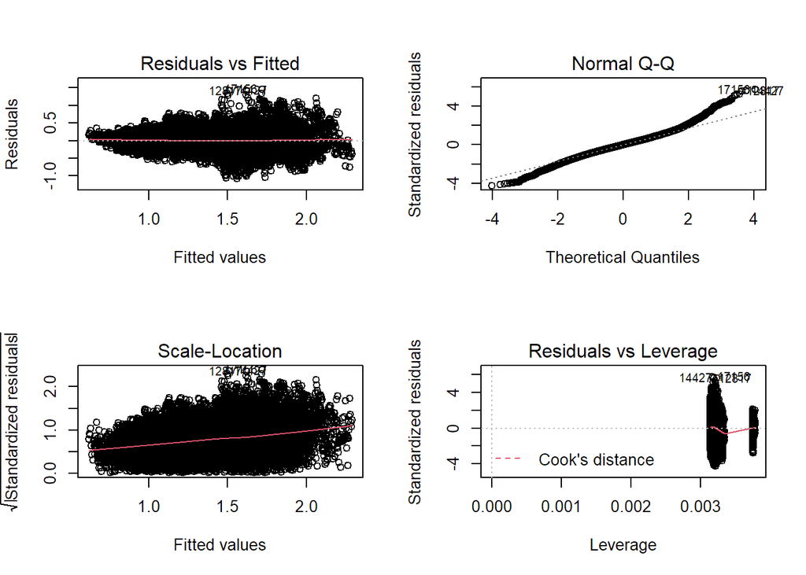

```r
par(mfrow = c(2, 2))
plot(mod_1)
```